# Rumsay, Chapter 5: Undestanding probability basis

Maurizio Murino

4 March 2016

```r
knitr::opts_chunk$set(cache=TRUE, warning=FALSE, message=FALSE, fig.width=12)
```

```r
library(lattice)
library(knitr)
```

### Exercise 1 - 4/3/’16

Balls colors: “brown” 13%, “yellow” 14%, “red” 13%, “blue” 24%, “orange” 20%, “green” 16%.

[figure not shown]

```r
# There is no sample dimension. I make a n = 100 dataframe.

e3 <- data.frame(color = rep(c("brown", "yellow", "red", "blue", "orange", "green"), c(13, 14, 13, 24, 20, 16)))
barchart(~table(color), data = e3,
         xlab = "Percentage",
         horizontal = FALSE,
         main = "Balls (no N)")
```

**A. What is the chance that you extract a brown or yellow ball?**

It is the sum of the quantities of yellow and brown balls on the total, that is:

```r
paste((13 + 14), "%", sep = "")
```

```
## [1] "27%"
```

**B. What is the chance that you will not pull out a blue?**

Blue balls represent the 24% of the pool. Hence, the probability of not extracting it is:

```r
paste((100 - 24), "%", sep = "")
```

```
## [1] "76%"
```

### Exercise 2 - 6/3/’16

Flip a coin four times and have four head. Does this outcome give you the idea that the coin is not fair?

**Solution:**

We do not have enough data to answer this question. Four coin tosses produce `2^4 = 16` possible results. Four heads represents a single possible result, hence the probability of getting it is `1/16 = .06`. It is not likely, but it is possible.

### Exercise 3 - 6/3/’16

Toss a fair coin 10 times, and record how many heads occur.

**A. How many are the possible outcomes?**

```r
2 ^ 10
```

```
## [1] 1024
```

**B. What would be the probability of each of the outcomes?**

```r
paste(round((1 / 1024), 3), "%", sep = "")
```

```
## [1] "0.001%"
```

**c. How many of the outcomes would have one head? What is the probability of one head on ten flips.**

A possible solution id HTTTTTTTTTT, but I could have a head at any toss, such as the second THTTTTTTTT and so forth. Hence, we can count 10 possible outcomes:

```r
paste(round((10 / 1024), 2), "%", sep = "")
```

```
## [1] "0.01%"
```

**D. How many of the outomes would have zero heads? What is the probability of zero heads in ten filps?**

Only one possible result has no heads.

```r
paste(round((1/1024), 3), "%", sep = "")
```

```
## [1] "0.001%"
```

**E. What is the probability of getting one head or less on 10 flips?**

There are eleven possible results, hence:

```r
paste(round((11/1024), 2), "%", "")
```

```
## [1] "0.01 % "
```

### Exercise 4 - 9/3/’16

What is the probability of getting more than one head on 10 flips of a fair coin?

```r
paste(round(1 - (11/1024), 3), "%", sep = "")
```

```
## [1] "0.989%"
```

### Exercise 5 - 9/3/’16

Suppose a basket player’2 free-throw shooting percentage is 70%.

**A. Explain what it means as a probability.**

It means that on the long term the player should perform the 70% of correct throws, as average.

**B. What is wrong with thinking that his chances of making his next free throw are 50-50.**

Because the 70% is produced by a long time observation of his performances. Probability does not tell us what is gung to happening, but just how, in the long term, it should result.

### Exercise 6 - 6/3/’16

Suppose you buy a lottery ticket, and you have to pick six numbers from 1 to 50 (repetions allowed). Which repetition is more likely to win: 13, 48, 17, 22, 6, 39 or 1, 2, 3, 4, 5, 6?

**Solution:**

They are equally likely, since every number picked does not depend from the other numbers already extracted.

### Exercise 7 - 6/3/’16

You feel lucky again and buy a handful of instant lottery tickets. The last three tickes give you one dollar! Should you play again because you are “on a roll”?

**Solution:**

No, of course. Those are “winning-traps”, giving you the illusion that a real victory is really possible. Such a small trend tells us nothing about the possible resul of the next ticket. Simply, there are more ticket where you do not win: in the end, you will always lose.

### Exercise 8 - 9/3/’16

Suppose that a small town has five people with a rare form of cancer. Does this automatically mean that a huge problem exists that need to be addresses?

**Solution:**

Since the illness is rare, we could suspect a problem in that particular area, even if not necessarily. More information about the time of the appearence of the illness could be useful to produce a more useful deduction.

### Exercise 9 - 9/3/’16

A couple has conceived three girls so far a fourth baby on the way. Do you predict that the newborn could be a girl or a boy? Why?

**Solution:**

The chance is 50-50, since there is no relation between the sex f the newborn and the sex of his/her sisters.

### Exercise 10 - 9/3/’16

Meteorologists use computer models to predict when and where hurrican will hit shore. Suppose they predict that hurrican Stat has 20% chance of hitting the east coast.

**A. On what info are the meteorologist basing this prediction?**

Simulators are based on the historical data collected from previous events.

**B. Why is this prediction harder to make than your chance of getting a head on your next coin toss?**

Coin flips are equally likely, 50-50. Past hurricanes hit the east cost in average the 20% of cases. It is not harder, it is only based on different data, especially in simulators, where many data input are blank due to lack of information.

### Exercise 11 - 9/3/’16

Bob stayed at the slot four hours. He think the longer he will stay, the better chance he has to win eventually. Is Bob right?

**Solution:**

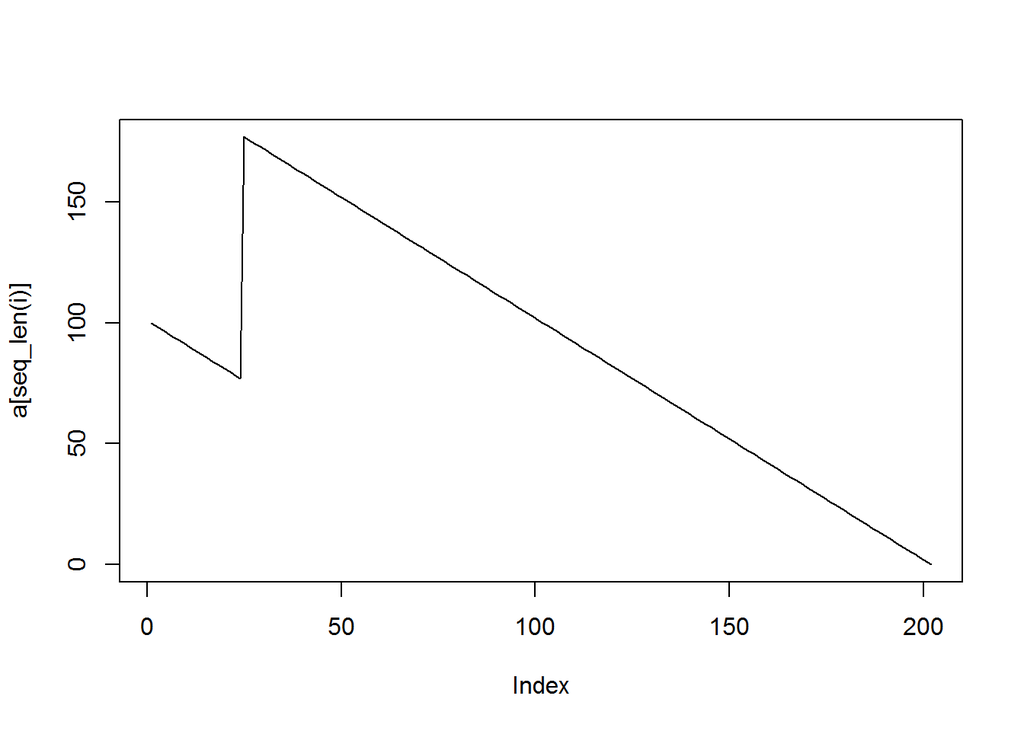

```r
set.seed(123)


n <- 1e6
a <- rep(NA_integer_, n)
a[1] <- 100L # set initial value (integer)
i <- 1 # counter
while(a[i] > 0) {
  # first check whether our results will fit. If not, embiggenate `a`.
  if(i==length(a)) a <- c(a, rep(NA_integer_, n))
  if (rbinom(1, 1, 0.01) == 1) {
    a[i+1] <- a[i] + 100L
  } else {
    a[i+1] <- a[i] - 1L
  }
  i <- i + 1
}

plot(a[seq_len(i)], type = "l")
```

### Exercise 12 - 9/3/’16

Which situation is more likely to produce exactly 50 percent heads: flipping a coin 10 times or 10000?

**Solution:**

Probability works on the long run, hence the correct answer is 10000. Let’s try a simulation of the problem.

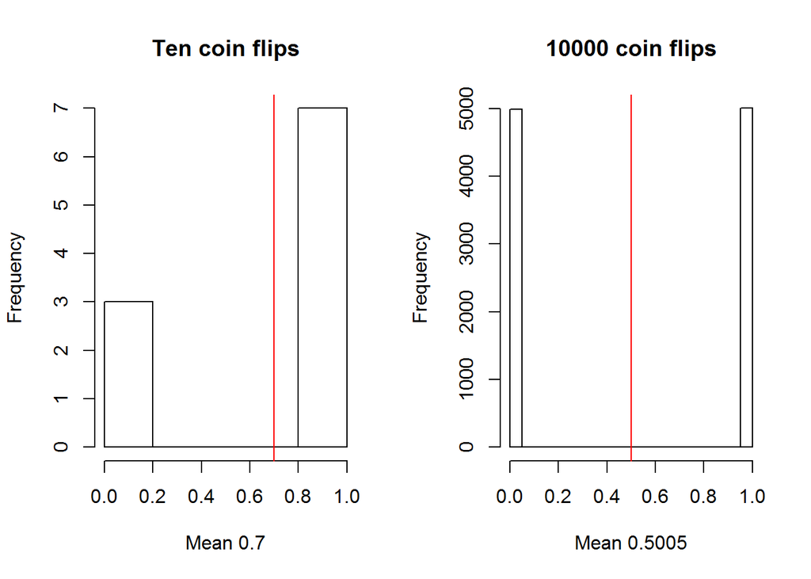

```r
set.seed(1234)
ten_fl <- sample(0:1, 10, replace = TRUE)
thous_fl <- (sample(0:1, 10000, replace = TRUE))

par(mfrow = c(1, 2))

plot_ten_fl <- hist(ten_fl, main = "Ten coin flips", xlab = paste("Mean", mean(ten_fl), sep = " "))
abline(v = mean(ten_fl), col = "red")

plot_thous_fl <- hist(thous_fl, main = "10000 coin flips", xlab = paste("Mean", mean(thous_fl), sep = " "))
abline(v = mean(thous_fl), col = "red")
```

As we can see, the mean tends more toward the center of the distribution (0.5) on 10000 flips.